# Donor Profile: Italy (Government of)

## Focus Portfolio

Italy’s funding portfolio exhibits significant concentration disparities, with total funding per region ranging from 394,000 to over 12.9 million, averaging approximately 3.7 million. This variance signals untapped potential in underfunded areas that can leverage existing resources for scalable impact. Notably, 25% of funding allocations fall below 1.2 million, indicating high-leverage entry points for donors focusing on emergency response and resilience. Investing to balance this funding distribution offers an impact multiplier effect by reinforcing weaker regions and optimizing overall portfolio performance. To maximize resource allocation efficiency, donor partnerships should prioritize regions with suboptimal funding but high strategic relevance. Immediate attention to this funding gap can mitigate risks of localized underperformance and bolster UNHCR’s accountability commitments. We recommend positioning targeted investments as strategic priorities that amplify both innovation capacity and emergency response readiness, thereby aligning with major donors’ agendas for sustainable impact. Strategic engagement leveraging these data-driven insights can unlock new funding avenues and deepen collaboration, accelerating humanitarian outcomes. Decision-makers should capitalize on this evidence to recalibrate funding approaches and activate tailored donor value propositions.

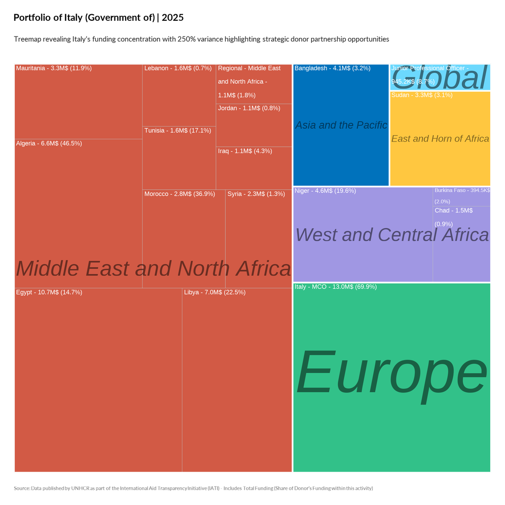

TRUE

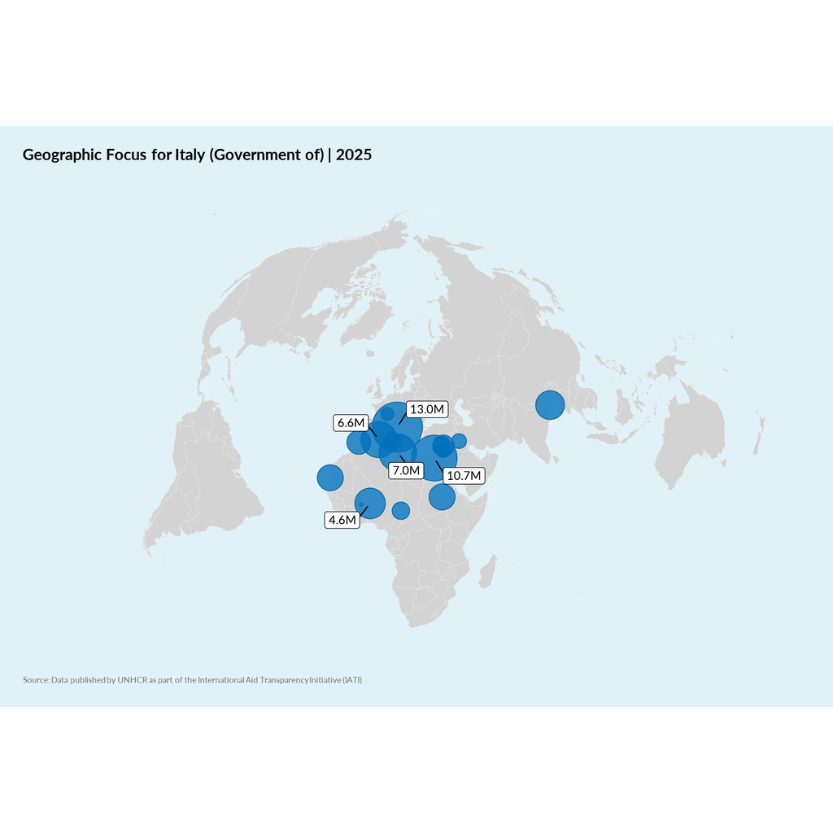

TRUE